# Data_Sci_Project

## CMPS 3160 - Milestone 1 - Nora and Kyle

### Predicting Equity Returns Using Macroeconomic and Fundamental Indicators Across Multiple Financial Databases

#### https://nora070.github.io/

```python
import pandas as pd
import numpy as np
import matplotlib.pyplot as plt
import seaborn as sns

from google.colab import drive
drive.mount('/content/drive')
```

### Abstract:

Combining these sources into one dataset, we hope to investigate which indicator may be the most predictive, which variables hurt equity performance, and if the combination of disparate sources can contribute to a more informed investment strategy.

### Collaboration plan:

We have a shared Google Drive folder containing our Notebook, data sets, and Doc to draft ideas and make a to-do list. We communicate via email and determine which parts of each milestone we're each responsible for. We check in throughout the working process, and ask for feedback and help as needed.

### Data Description:

The first data set we will be investigating is from the St. Louis Federal Reserve Bank. This data set contains four attributes;

Federal Funds Rate: The rate depository institutions (mainly banks) lend reserve balances to other depository institutions overnight, set by the Federal Open Market Committee (FOMC).

Consumer Price Index (CPI) inflation: measures the average change over time in prices paid by urban consumers for a representative "basket" of goods and services. It is a key economic indicator used to gauge the purchasing power of currency and cost-of-living changes.

10-year minus 2-year treasury yield spread: Compares the return rates of long and short term investments, such as bonds. Can serve as an indicator for consumer confidence and serve as a barometer for the economy.

Unemployment rate: The percentage of the laborforce that doesn't have a job.

Source: https://fred.stlouisfed.org/

Data pulled using an API key

This data set has one observation for the first of each month from 2005 to 2025.

Although this data set does not contain our target variable of equity return, it can help represent and quantify critical, but more abstract, factors such as consumer confidence.

### Pre-processing

```python
%cd '/content/drive/MyDrive/Loyno/2025-26/Spring/Data Science project/Data Science Project/Data'
fred = pd.read_csv('fred.csv')
fred.head()
```

```
/content/drive/.shortcut-targets-by-id/1VFLQdrQVJtQB7kwQoDRwKyhoQdSsj7-f/Data Science Project/Data
```

|  | Date | Fed_Funds_Rate | CPI | Yield_Spread | Unemployment |
| --- | --- | --- | --- | --- | --- |
| 0 | 1/1/2005 | 2.28 | 191.6 | 1.00 | 5.3 |
| 1 | 2/1/2005 | 2.50 | 192.4 | 0.79 | 5.4 |
| 2 | 3/1/2005 | 2.63 | 193.1 | 0.77 | 5.2 |
| 3 | 4/1/2005 | 2.79 | 193.7 | 0.69 | 5.2 |
| 4 | 5/1/2005 | 3.00 | 193.6 | 0.50 | 5.1 |

For this data set, we hope to identify trends in hindsight using consumer confidence economic indicators, and then try to apply those trends to make more accurate future predictions.

One specific question we could ask: Which indicator out of these four is the most correlated with equity return values?

```python
fred.info()
```

```
<class 'pandas.core.frame.DataFrame'>
RangeIndex: 241 entries, 0 to 240
Data columns (total 5 columns):
 #   Column          Non-Null Count  Dtype
---  ------          --------------  -----
 0   Date            241 non-null    object
 1   Fed_Funds_Rate  241 non-null    float64
 2   CPI             241 non-null    float64
 3   Yield_Spread    241 non-null    float64
 4   Unemployment    241 non-null    float64
dtypes: float64(4), object(1)
memory usage: 9.5+ KB
```

First, check if our data types look appropriate. The last four are appropriately labeled as numerical floats, but the data is mischaracterized as an object. Lets use pandas internal function to fix that.

```python
# Convert the 'Date' column to datetime objects
fred['Date'] = pd.to_datetime(fred['Date'])
fred.info()
```

```
<class 'pandas.core.frame.DataFrame'>
RangeIndex: 241 entries, 0 to 240
Data columns (total 5 columns):
 #   Column          Non-Null Count  Dtype
---  ------          --------------  -----
 0   Date            241 non-null    datetime64[ns]
 1   Fed_Funds_Rate  241 non-null    float64
 2   CPI             241 non-null    float64
 3   Yield_Spread    241 non-null    float64
 4   Unemployment    241 non-null    float64
dtypes: datetime64[ns](1), float64(4)
memory usage: 9.5 KB
```

Great! Now lets deal with any missing values.

```python
fred.shape
```

```
(241, 5)
```

We can see the total number of rows matches the number of non-null values in each column, so we have no missing data.

Now lets scale our data. If we end up using this data to model later, we will split into train and test before scaling.

```python
from sklearn.preprocessing import MinMaxScaler
scaler = MinMaxScaler()

fred_scaled = fred.copy()
fred_scaled[['Fed_Funds_Rate', 'CPI', 'Yield_Spread', 'Unemployment']] = scaler.fit_transform(fred[['Fed_Funds_Rate', 'CPI', 'Yield_Spread', 'Unemployment']])
fred_scaled.head()
```

|  | Date | Fed_Funds_Rate | CPI | Yield_Spread | Unemployment |
| --- | --- | --- | --- | --- | --- |
| 0 | 2005-01-01 | 0.422348 | 0.000000 | 0.513298 | 0.166667 |
| 1 | 2005-02-01 | 0.464015 | 0.006281 | 0.457447 | 0.175439 |
| 2 | 2005-03-01 | 0.488636 | 0.011778 | 0.452128 | 0.157895 |
| 3 | 2005-04-01 | 0.518939 | 0.016489 | 0.430851 | 0.157895 |
| 4 | 2005-05-01 | 0.558712 | 0.015703 | 0.380319 | 0.149123 |

Great! Now we can see an easy, scaled visualization of our four stats over time.

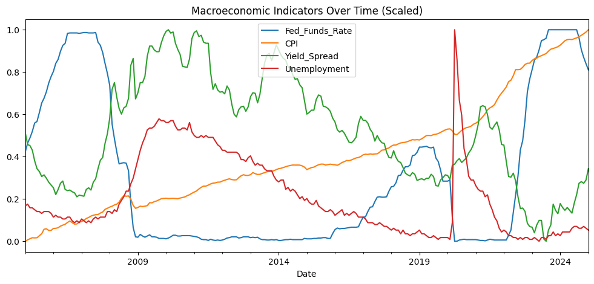

```python
fred_scaled.plot(x='Date', figsize=(12,5), title='Macroeconomic Indicators Over Time (Scaled)')
plt.show()
```

This graphic shows interesting and well known financial crisis points, such as the 2008 crash and the COVID19 recession. Correctly integrating the date column into our other data sets will be important for historical contexualization. For example, lets use this data to find a few interesting facts about the last two decades.

```python
print(f"Peak unemployment: {fred['Unemployment'].max()}% in {fred.loc[fred['Unemployment'].idxmax(), 'Date']}")
print(f"Average Fed Funds Rate: {fred['Fed_Funds_Rate'].mean()}%")
```

```
Peak unemployment: 14.8% in 2020-04-01 00:00:00
Average Fed Funds Rate: 1.697136929460581%
```

Lets produce the correlation matrix to see how closely our data correlates to eachother. This will be an important method as we build our dataset to include more and more factors. The date won't correlate directly to any of these values, so lets drop it for now.

```python
fred_scaled = fred_scaled.drop(columns=['Date'])
fred_scaled.corr()
```

|  | Fed_Funds_Rate | CPI | Yield_Spread | Unemployment |
| --- | --- | --- | --- | --- |
| Fed_Funds_Rate | 1.000000 | 0.197258 | -0.762078 | -0.579041 |
| CPI | 0.197258 | 1.000000 | -0.489609 | -0.412829 |
| Yield_Spread | -0.762078 | -0.489609 | 1.000000 | 0.738344 |
| Unemployment | -0.579041 | -0.412829 | 0.738344 | 1.000000 |

The highest correlation appears to be a negative relationship between Yield Spread and Federal Funds Rate. Lets plot just those two variables.

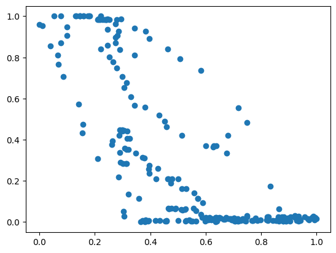

```python
plt.scatter(fred_scaled['Yield_Spread'], fred_scaled['Fed_Funds_Rate'])
```

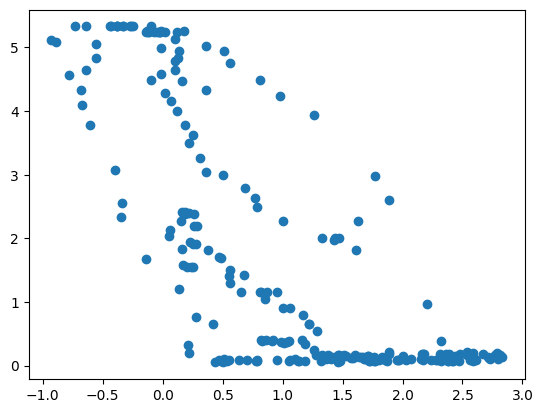

```python
plt.scatter(fred['Yield_Spread'], fred['Fed_Funds_Rate'])
```

We can see how scaling preserves the relationship between the data but puts the range into context.

### ETL

One interesting statistic that will be useful when other data is present is the average Federal Funds Rate. The Federal Funds Rate is an important metric for monetary policy in the U.S. and helps represents the cost of borrowing. This rate has an important function within financial markets since it affects different inputs in equity valuation models, which are models predicting what a company is or projected to be worth.

Lets calculate the average FFR from 2005 to 2025.

```python
print("Average FFR: ", fred['Fed_Funds_Rate'].mean())
```

```
Average FFR:  1.697136929460581
```

Another interesting statistic can be found in the yield spread, which is the difference between long term and short term treasury yields. Yield spreads are important for investing because it is a metric used when people are estimating a country’s economic growth, as well as their corporate earnings.

```python
print("Average Yield spread: ", fred['Yield_Spread'].mean())
```

```
Average Yield spread:  0.9943983402489627
```

Accross the entire date range, the average is approximately 1.0. However we also see periods where the average yield spread is negative, such as a long stretch from 2022 - 2024. When yield spreads are negative, it can be an indicator that an economy is slowing or that recession is near, which is extremely important to know when investing in certain companies that are recession proof or volatile to recession.

A third intriguing statistic lies within the Consumer Price Index, which measures inflation. Inflation affects equity markets and investments a lot because it changes the expenses within corporations, and also is a major influencer of monetary policy. An important timeframe within this data was the movements between 2020 and 2023, where the index rose from 258 to 305. This captures the inflation increase post pandemic from several economic problems such as supply chains and or energy prices. This shows how much an economy is based on current events. Another reason inflation is a relevant metric is because of its effect on interest rates. When inflation is higher, interest rates tend to become higher causing lower stock valuations. It is important to take this into account when investing in certain economic times.

The graphic below shows the relationship between CPI and the Federal Funds Rate. It shows how when inflation increases, interest rates often rise. Note the scalar multiplier applied to the FFR to make the changes more apparant on the current y-scale.

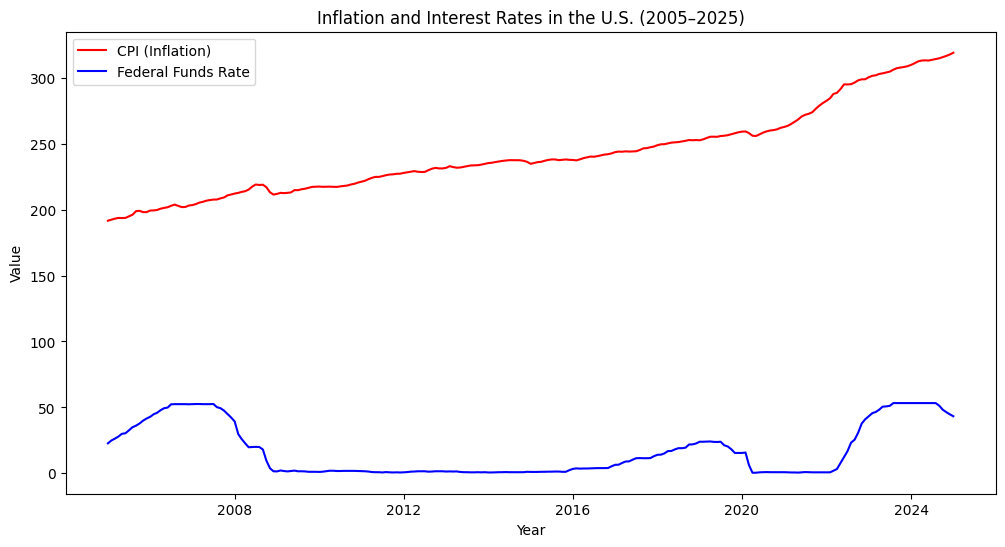

```python
plt.figure(figsize=(12,6))

plt.plot(fred['Date'], fred['CPI'], label='CPI (Inflation)', color='red')
plt.plot(fred['Date'], fred['Fed_Funds_Rate']*10, label='Federal Funds Rate', color='blue')
plt.xlabel("Year")
plt.ylabel("Value")
plt.title("Inflation and Interest Rates in the U.S. (2005–2025)")
plt.legend()

plt.show()
```

## Second Data Set

```python
%cd '/content/drive/MyDrive/Loyno/2025-26/Spring/Data Science project/Data Science Project/Data/DATA'
```

```
/content/drive/.shortcut-targets-by-id/1VFLQdrQVJtQB7kwQoDRwKyhoQdSsj7-f/Data Science Project/Data/DATA
```

Our next data set involves fundamental financial information from a wide range of publically traded companies, obtained through LSEG. We choose 5 different companies from 8 subsectors of the market to ensure a broad measure of the stock market environment.

```python
import glob

# Get a list of all csv files in the current directory
csv_files = glob.glob('*.csv')

# Initialize an empty list to store dataframes
lseg_list = []

# Loop through the list of csv files and read each into a dataframe
for file in csv_files:
    df = pd.read_csv(file)
    lseg_list.append(df)

# Concatenate all dataframes in the list into a single dataframe
lseg = pd.concat(lseg_list, ignore_index=True)

# Display the first 5 rows of the merged dataframe
display(lseg.head())
```

|  | Ticker | year_ | InfoCode | MarketDate | typ | code | coderank | inforank | freq | ITEM5350 | ... | ITEM8301 | ITEM8306 | ITEM8311 | ITEM8316 | ITEM8326 | ITEM8366 | ITEM8376 | ITEM8601 | ITEM8631 | ITEM8636 |
| --- | --- | --- | --- | --- | --- | --- | --- | --- | --- | --- | --- | --- | --- | --- | --- | --- | --- | --- | --- | --- | --- |
| 0 | COP | 2004.0 | 63203 | 11/29/2005 | 1.0 | 46422.0 | 1.0 | 1.0 | A | 2004-12-31 | ... | 21.08991 | 14.03651 | 10.57960 | 11.29221 | 9.68421 | 6.84726 | 15.17448 | 72.68657 | 31.19426 | 71.67899 |
| 1 | COP | 2005.0 | 63203 | 11/07/2006 | 1.0 | 46422.0 | 1.0 | 1.0 | A | 2005-12-31 | ... | 28.34664 | 14.78033 | 10.70287 | 12.58459 | 13.86987 | 8.33041 | 22.11269 | 66.46500 | 36.79782 | 66.42884 |
| 2 | COP | 2006.0 | 63203 | 01/04/2007 | 1.0 | 46422.0 | 1.0 | 1.0 | A | 2006-12-31 | ... | 22.97288 | 17.99043 | 13.81446 | 15.25439 | 11.96861 | 9.27926 | 18.32364 | 0.31153 | 3.18525 | 14.93828 |
| 3 | COP | 2007.0 | 63203 | 01/08/2008 | 1.0 | 46422.0 | 1.0 | 1.0 | A | 2007-12-31 | ... | 13.85663 | 16.37493 | 13.29446 | 13.25015 | 7.42032 | 6.93353 | 11.40397 | -25.25880 | 2.34040 | -23.53055 |
| 4 | COP | 2008.0 | 63203 | 01/05/2009 | 1.0 | 46422.0 | 1.0 | 1.0 | A | 2008-12-31 | ... | -23.58409 | 15.34619 | 10.50332 | 12.04220 | -10.22671 | -7.54046 | -16.76212 | NaN | 31.44257 | NaN |

5 rows × 25 columns

LSEG includes many financial variables, but we will only use some of them.

Item 8301 - Return on Equity - Total (%)

Item 8326 - Return on Assets

Item 8376 - Return on Invested Capital

Item 8306 - Gross Profit Margin

Imes 8366 - Net Margin

Item 8316 - Operating Profit Margin

Item 8231 - Total Debt % Common Equity

Item 8216 - Long Term Debt % Total Capital

Item 8291 - EBIT/Interest Expense

Item 8106 - Current Ratio

Item 8101 - Quick Ratio

Item 8631 - Net Sales / Revenues - 1 Yr Annual Growth

Item 8601 - Earnings Per Share - 1 Yr Annual Growth

Item 8636 - Net Income - 1 Yr Annual Growth

Item 8311 - Cash Flow/Sales

```python
# Rename columns for financial info contextualization
lseg.columns = ['Ticker', 'year_', 'InfoCode', 'MarketDate', 'typ', 'code', 'coderank',
       'inforank', 'freq', 'FiscalCloseDate', 'QuickRatio', 'CurrentRatio', 'LongTermDebtToCapital',
       'TotalDebtToEquity', 'EBITToInterestExpense', 'ReturnOnEquityToTotal', 'GrossProfitMargin', 'CashFlowToSales', 'OperatingProfitMargin',
       'ReturnOnAssets', 'NetMargin', 'ReturnOnInvestedCapital', 'EarningPerShare1Yr', 'NetSaleToRev1Yr', 'NetIncome1Yr']

lseg.head()
```

|  | Ticker | year_ | InfoCode | MarketDate | typ | code | coderank | inforank | freq | FiscalCloseDate | ... | ReturnOnEquityToTotal | GrossProfitMargin | CashFlowToSales | OperatingProfitMargin | ReturnOnAssets | NetMargin | ReturnOnInvestedCapital | EarningPerShare1Yr | NetSaleToRev1Yr | NetIncome1Yr |
| --- | --- | --- | --- | --- | --- | --- | --- | --- | --- | --- | --- | --- | --- | --- | --- | --- | --- | --- | --- | --- | --- |
| 0 | COP | 2004.0 | 63203 | 11/29/2005 | 1.0 | 46422.0 | 1.0 | 1.0 | A | 2004-12-31 | ... | 21.08991 | 14.03651 | 10.57960 | 11.29221 | 9.68421 | 6.84726 | 15.17448 | 72.68657 | 31.19426 | 71.67899 |
| 1 | COP | 2005.0 | 63203 | 11/07/2006 | 1.0 | 46422.0 | 1.0 | 1.0 | A | 2005-12-31 | ... | 28.34664 | 14.78033 | 10.70287 | 12.58459 | 13.86987 | 8.33041 | 22.11269 | 66.46500 | 36.79782 | 66.42884 |
| 2 | COP | 2006.0 | 63203 | 01/04/2007 | 1.0 | 46422.0 | 1.0 | 1.0 | A | 2006-12-31 | ... | 22.97288 | 17.99043 | 13.81446 | 15.25439 | 11.96861 | 9.27926 | 18.32364 | 0.31153 | 3.18525 | 14.93828 |
| 3 | COP | 2007.0 | 63203 | 01/08/2008 | 1.0 | 46422.0 | 1.0 | 1.0 | A | 2007-12-31 | ... | 13.85663 | 16.37493 | 13.29446 | 13.25015 | 7.42032 | 6.93353 | 11.40397 | -25.25880 | 2.34040 | -23.53055 |
| 4 | COP | 2008.0 | 63203 | 01/05/2009 | 1.0 | 46422.0 | 1.0 | 1.0 | A | 2008-12-31 | ... | -23.58409 | 15.34619 | 10.50332 | 12.04220 | -10.22671 | -7.54046 | -16.76212 | NaN | 31.44257 | NaN |

5 rows × 25 columns

```python
lseg = lseg.drop(columns=['MarketDate', 'FiscalCloseDate', 'InfoCode', 'typ', 'code', 'coderank', 'inforank', 'freq'])
lseg.head()
```

|  | Ticker | year_ | QuickRatio | CurrentRatio | LongTermDebtToCapital | TotalDebtToEquity | EBITToInterestExpense | ReturnOnEquityToTotal | GrossProfitMargin | CashFlowToSales | OperatingProfitMargin | ReturnOnAssets | NetMargin | ReturnOnInvestedCapital | EarningPerShare1Yr | NetSaleToRev1Yr | NetIncome1Yr |
| --- | --- | --- | --- | --- | --- | --- | --- | --- | --- | --- | --- | --- | --- | --- | --- | --- | --- |
| 0 | COP | 2004.0 | 0.65283 | 0.96375 | 24.69157 | 35.11458 | 13.74180 | 21.08991 | 14.03651 | 10.57960 | 11.29221 | 9.68421 | 6.84726 | 15.17448 | 72.68657 | 31.19426 | 71.67899 |
| 1 | COP | 2005.0 | 0.66267 | 0.91821 | 16.62803 | 23.73556 | 23.11659 | 28.34664 | 14.78033 | 10.70287 | 12.58459 | 13.86987 | 8.33041 | 22.11269 | 66.46500 | 36.79782 | 66.42884 |
| 2 | COP | 2006.0 | 0.56460 | 0.94836 | 21.59268 | 32.83159 | 16.38058 | 22.97288 | 17.99043 | 13.81446 | 15.25439 | 11.96861 | 9.27926 | 18.32364 | 0.31153 | 3.18525 | 14.93828 |
| 3 | COP | 2007.0 | 0.66253 | 0.92013 | 18.37023 | 24.37207 | 10.73982 | 13.85663 | 16.37493 | 13.29446 | 13.25015 | 7.42032 | 6.93353 | 11.40397 | -25.25880 | 2.34040 | -23.53055 |
| 4 | COP | 2008.0 | 0.58540 | 0.95698 | 32.49550 | 49.76888 | -4.54957 | -23.58409 | 15.34619 | 10.50332 | 12.04220 | -10.22671 | -7.54046 | -16.76212 | NaN | 31.44257 | NaN |

Now, we will work on merging this data frame with our FRED data. LSEG pulls the annual reports that companies release, so we have one entry per year for each company. We will extend this data by copying the rows so it will match our format of the first of every month.

```python
# Convert 'year_' to datetime objects representing the start of the year
lseg['Date'] = pd.to_datetime(lseg['year_'].astype(int), format='%Y')

# Create a list to store expanded rows
expanded_rows = []

# Iterate over each row in the lseg dataframe
for index, row in lseg.iterrows():
    base_date = row['Date']
    # Generate 12 months for each year
    for month_offset in range(12):
        new_date = base_date + pd.DateOffset(months=month_offset)
        new_row = row.copy()
        new_row['Date'] = new_date
        expanded_rows.append(new_row)

# Create the new expanded dataframe
lseg_expanded = pd.DataFrame(expanded_rows)

# Drop the original 'year_' column as it's replaced by 'Date'
lseg_expanded = lseg_expanded.drop(columns=['year_'])

#Put new data column back at the front of the dataframe
lseg_expanded.insert(1, 'Date', lseg_expanded.pop('Date'))

# Display the head of the expanded DataFrame to verify
display(lseg_expanded.head())
```

|  | Ticker | Date | QuickRatio | CurrentRatio | LongTermDebtToCapital | TotalDebtToEquity | EBITToInterestExpense | ReturnOnEquityToTotal | GrossProfitMargin | CashFlowToSales | OperatingProfitMargin | ReturnOnAssets | NetMargin | ReturnOnInvestedCapital | EarningPerShare1Yr | NetSaleToRev1Yr | NetIncome1Yr |
| --- | --- | --- | --- | --- | --- | --- | --- | --- | --- | --- | --- | --- | --- | --- | --- | --- | --- |
| 0 | COP | 2004-01-01 | 0.65283 | 0.96375 | 24.69157 | 35.11458 | 13.7418 | 21.08991 | 14.03651 | 10.5796 | 11.29221 | 9.68421 | 6.84726 | 15.17448 | 72.68657 | 31.19426 | 71.67899 |
| 0 | COP | 2004-02-01 | 0.65283 | 0.96375 | 24.69157 | 35.11458 | 13.7418 | 21.08991 | 14.03651 | 10.5796 | 11.29221 | 9.68421 | 6.84726 | 15.17448 | 72.68657 | 31.19426 | 71.67899 |
| 0 | COP | 2004-03-01 | 0.65283 | 0.96375 | 24.69157 | 35.11458 | 13.7418 | 21.08991 | 14.03651 | 10.5796 | 11.29221 | 9.68421 | 6.84726 | 15.17448 | 72.68657 | 31.19426 | 71.67899 |
| 0 | COP | 2004-04-01 | 0.65283 | 0.96375 | 24.69157 | 35.11458 | 13.7418 | 21.08991 | 14.03651 | 10.5796 | 11.29221 | 9.68421 | 6.84726 | 15.17448 | 72.68657 | 31.19426 | 71.67899 |
| 0 | COP | 2004-05-01 | 0.65283 | 0.96375 | 24.69157 | 35.11458 | 13.7418 | 21.08991 | 14.03651 | 10.5796 | 11.29221 | 9.68421 | 6.84726 | 15.17448 | 72.68657 | 31.19426 | 71.67899 |

Perfect! Now we are ready to merge our data sets. We will be using the default inner merge on Date, which will drop any entries that don't have a matching date. This will be our substitute to manually slicing both data frames to end on the same year, as they're coming in with a small difference.

```python
lseg_fred = pd.merge(lseg_expanded, fred, on='Date')
lseg_fred.head()
```

|  | Ticker | Date | QuickRatio | CurrentRatio | LongTermDebtToCapital | TotalDebtToEquity | EBITToInterestExpense | ReturnOnEquityToTotal | GrossProfitMargin | CashFlowToSales | ... | ReturnOnAssets | NetMargin | ReturnOnInvestedCapital | EarningPerShare1Yr | NetSaleToRev1Yr | NetIncome1Yr | Fed_Funds_Rate | CPI | Yield_Spread | Unemployment |
| --- | --- | --- | --- | --- | --- | --- | --- | --- | --- | --- | --- | --- | --- | --- | --- | --- | --- | --- | --- | --- | --- |
| 0 | COP | 2005-01-01 | 0.66267 | 0.91821 | 16.62803 | 23.73556 | 23.11659 | 28.34664 | 14.78033 | 10.70287 | ... | 13.86987 | 8.33041 | 22.11269 | 66.465 | 36.79782 | 66.42884 | 2.28 | 191.6 | 1.00 | 5.3 |
| 1 | COP | 2005-02-01 | 0.66267 | 0.91821 | 16.62803 | 23.73556 | 23.11659 | 28.34664 | 14.78033 | 10.70287 | ... | 13.86987 | 8.33041 | 22.11269 | 66.465 | 36.79782 | 66.42884 | 2.50 | 192.4 | 0.79 | 5.4 |
| 2 | COP | 2005-03-01 | 0.66267 | 0.91821 | 16.62803 | 23.73556 | 23.11659 | 28.34664 | 14.78033 | 10.70287 | ... | 13.86987 | 8.33041 | 22.11269 | 66.465 | 36.79782 | 66.42884 | 2.63 | 193.1 | 0.77 | 5.2 |
| 3 | COP | 2005-04-01 | 0.66267 | 0.91821 | 16.62803 | 23.73556 | 23.11659 | 28.34664 | 14.78033 | 10.70287 | ... | 13.86987 | 8.33041 | 22.11269 | 66.465 | 36.79782 | 66.42884 | 2.79 | 193.7 | 0.69 | 5.2 |
| 4 | COP | 2005-05-01 | 0.66267 | 0.91821 | 16.62803 | 23.73556 | 23.11659 | 28.34664 | 14.78033 | 10.70287 | ... | 13.86987 | 8.33041 | 22.11269 | 66.465 | 36.79782 | 66.42884 | 3.00 | 193.6 | 0.50 | 5.1 |

5 rows × 21 columns

```python
display(lseg_fred.sort_values(by='Date'))
```

|  | Ticker | Date | QuickRatio | CurrentRatio | LongTermDebtToCapital | TotalDebtToEquity | EBITToInterestExpense | ReturnOnEquityToTotal | GrossProfitMargin | CashFlowToSales | ... | ReturnOnAssets | NetMargin | ReturnOnInvestedCapital | EarningPerShare1Yr | NetSaleToRev1Yr | NetIncome1Yr | Fed_Funds_Rate | CPI | Yield_Spread | Unemployment |
| --- | --- | --- | --- | --- | --- | --- | --- | --- | --- | --- | --- | --- | --- | --- | --- | --- | --- | --- | --- | --- | --- |
| 0 | COP | 2005-01-01 | 0.66267 | 0.91821 | 16.62803 | 23.73556 | 23.11659 | 28.34664 | 14.78033 | 10.70287 | ... | 13.86987 | 8.33041 | 22.11269 | 66.46500 | 36.79782 | 66.42884 | 2.28 | 191.600 | 1.00 | 5.3 |
| 4308 | PFE | 2005-01-01 | 1.14247 | 1.47272 | 8.81846 | 27.40078 | 24.60041 | 12.09947 | 77.11997 | 29.86276 | ... | 7.00649 | 15.76085 | 9.84958 | -26.84564 | -2.31929 | -28.97303 | 2.28 | 191.600 | 1.00 | 5.3 |
| 4068 | MRK | 2005-01-01 | 1.39549 | 1.58224 | 20.14036 | 45.19608 | 15.96394 | 26.31062 | 77.40995 | 29.20239 | ... | 11.17906 | 21.03998 | 17.75576 | -19.54023 | -4.03992 | -20.33406 | 2.28 | 191.600 | 1.00 | 5.3 |
| 3828 | JNJ | 2005-01-01 | 1.83205 | 2.48469 | 5.05666 | 7.08986 | 83.09091 | 29.87589 | 72.37597 | 25.31773 | ... | 18.92118 | 20.61013 | 27.77295 | 11.61290 | 6.68666 | 22.35280 | 2.28 | 191.600 | 1.00 | 5.3 |
| 3588 | ABT | 2005-01-01 | 0.88098 | 1.53543 | 24.07731 | 46.01727 | 16.34846 | 23.46515 | 53.14173 | 22.38570 | ... | 12.18796 | 15.09577 | 16.74264 | 4.85437 | 13.50503 | 4.20953 | 2.28 | 191.600 | 1.00 | 5.3 |
| ... | ... | ... | ... | ... | ... | ... | ... | ... | ... | ... | ... | ... | ... | ... | ... | ... | ... | ... | ... | ... | ... |
| 4787 | UNH | 2024-12-01 | NaN | NaN | 41.35982 | 81.05055 | 6.13850 | 15.52171 | NaN | 6.00273 | ... | 6.11566 | 3.60514 | 10.25997 | -35.01383 | 7.59992 | -35.63737 | 4.48 | 317.604 | 0.16 | 4.1 |
| 5483 | MCD | 2024-12-01 | 0.89821 | 1.19114 | 110.43218 | -1058.86226 | 7.65314 | NaN | 55.02701 | 38.14043 | ... | 17.96961 | 31.72454 | 25.92252 | -1.50363 | 1.67218 | -2.90242 | 4.48 | 317.604 | 0.16 | 4.1 |
| 5723 | NKE | 2024-12-01 | 1.51128 | 2.39611 | 35.38710 | 61.73943 | 25.90706 | 40.09285 | 44.56018 | 13.06997 | ... | 17.55496 | 11.09770 | 25.55325 | -5.34580 | 0.28311 | 12.42604 | 4.48 | 317.604 | 0.16 | 4.1 |
| 239 | COP | 2024-12-01 | 1.05650 | 1.29058 | 26.43923 | 37.53935 | 12.36663 | 16.16130 | 29.28852 | 37.09015 | ... | 8.99533 | 16.83807 | 12.50390 | -13.82883 | -2.48660 | -15.60154 | 4.48 | 317.604 | 0.16 | 4.1 |
| 9551 | SO | 2024-12-01 | 0.33946 | 0.66867 | 61.57457 | 195.20597 | 2.54153 | 13.61443 | 56.60081 | 31.30894 | ... | 4.61702 | 16.46834 | 6.61018 | 10.28740 | 5.82505 | 10.68913 | 4.48 | 317.604 | 0.16 | 4.1 |

9552 rows × 21 columns

The last non-numerical data remaining is 'Ticker'. This is the name of the individual stock. It doesn't serve as a good index due to non-uinqueness, but also isn't useful for regression because it's categorical. We will drop it when doing regression, but for now, we will use it to create a more visually simple representation of our data in a Pivot table. The data is now grouped by stock, and each row is a date entry for that stock.

```python
# Get all numerical columns except 'Ticker' and 'Date' for values
numerical_cols = lseg_fred.select_dtypes(include=np.number).columns.tolist()
pivot_values = [col for col in numerical_cols if col not in ['Date']]

# Create the pivot table
pivot_df = pd.pivot_table(lseg_fred, values=pivot_values, index=['Ticker', 'Date'], aggfunc=np.mean)

# Sort the pivot table by Ticker and then by Date
pivot_df = pivot_df.sort_values(by=['Ticker', 'Date'])

# Display the first few rows of the pivot table
display(pivot_df)
```

| Ticker | Date | CPI | CashFlowToSales | CurrentRatio | EBITToInterestExpense | EarningPerShare1Yr | Fed_Funds_Rate | GrossProfitMargin | LongTermDebtToCapital | NetIncome1Yr | NetMargin | NetSaleToRev1Yr | OperatingProfitMargin | QuickRatio | ReturnOnAssets | ReturnOnEquityToTotal | ReturnOnInvestedCapital | TotalDebtToEquity | Unemployment | Yield_Spread |
| --- | --- | --- | --- | --- | --- | --- | --- | --- | --- | --- | --- | --- | --- | --- | --- | --- | --- | --- | --- | --- |
| AAPL | 2005-01-01 | 191.600 | 14.85895 | 2.95637 | NaN | 198.41915 | 2.28 | 29.02161 | 0.00000 | 383.69565 | 9.58294 | 68.26911 | 11.84409 | 2.74770 | 13.81130 | 21.28847 | 21.28847 | 0.0000 | 5.3 | 1.00 |
|  | 2005-02-01 | 192.400 | 14.85895 | 2.95637 | NaN | 198.41915 | 2.50 | 29.02161 | 0.00000 | 383.69565 | 9.58294 | 68.26911 | 11.84409 | 2.74770 | 13.81130 | 21.28847 | 21.28847 | 0.0000 | 5.4 | 0.79 |
|  | 2005-03-01 | 193.100 | 14.85895 | 2.95637 | NaN | 198.41915 | 2.63 | 29.02161 | 0.00000 | 383.69565 | 9.58294 | 68.26911 | 11.84409 | 2.74770 | 13.81130 | 21.28847 | 21.28847 | 0.0000 | 5.2 | 0.77 |
|  | 2005-04-01 | 193.700 | 14.85895 | 2.95637 | NaN | 198.41915 | 2.79 | 29.02161 | 0.00000 | 383.69565 | 9.58294 | 68.26911 | 11.84409 | 2.74770 | 13.81130 | 21.28847 | 21.28847 | 0.0000 | 5.2 | 0.69 |
|  | 2005-05-01 | 193.600 | 14.85895 | 2.95637 | NaN | 198.41915 | 3.00 | 29.02161 | 0.00000 | 383.69565 | 9.58294 | 68.26911 | 11.84409 | 2.74770 | 13.81130 | 21.28847 | 21.28847 | 0.0000 | 5.1 | 0.50 |
| ... | ... | ... | ... | ... | ... | ... | ... | ... | ... | ... | ... | ... | ... | ... | ... | ... | ... | ... | ... | ... |
| XOM | 2024-08-01 | 314.062 | 16.75711 | 1.30840 | 19.22315 | -11.83824 | 5.33 | 22.37780 | 11.99118 | -6.47042 | 9.92787 | 1.35944 | 11.65257 | 0.95109 | 8.30734 | 14.37759 | 12.16461 | 15.8628 | 4.2 | -0.10 |
|  | 2024-09-01 | 314.732 | 16.75711 | 1.30840 | 19.22315 | -11.83824 | 5.13 | 22.37780 | 11.99118 | -6.47042 | 9.92787 | 1.35944 | 11.65257 | 0.95109 | 8.30734 | 14.37759 | 12.16461 | 15.8628 | 4.1 | 0.10 |
|  | 2024-10-01 | 315.631 | 16.75711 | 1.30840 | 19.22315 | -11.83824 | 4.83 | 22.37780 | 11.99118 | -6.47042 | 9.92787 | 1.35944 | 11.65257 | 0.95109 | 8.30734 | 14.37759 | 12.16461 | 15.8628 | 4.1 | 0.13 |
|  | 2024-11-01 | 316.528 | 16.75711 | 1.30840 | 19.22315 | -11.83824 | 4.64 | 22.37780 | 11.99118 | -6.47042 | 9.92787 | 1.35944 | 11.65257 | 0.95109 | 8.30734 | 14.37759 | 12.16461 | 15.8628 | 4.2 | 0.10 |
|  | 2024-12-01 | 317.604 | 16.75711 | 1.30840 | 19.22315 | -11.83824 | 4.48 | 22.37780 | 11.99118 | -6.47042 | 9.92787 | 1.35944 | 11.65257 | 0.95109 | 8.30734 | 14.37759 | 12.16461 | 15.8628 | 4.1 | 0.16 |

9552 rows × 19 columns

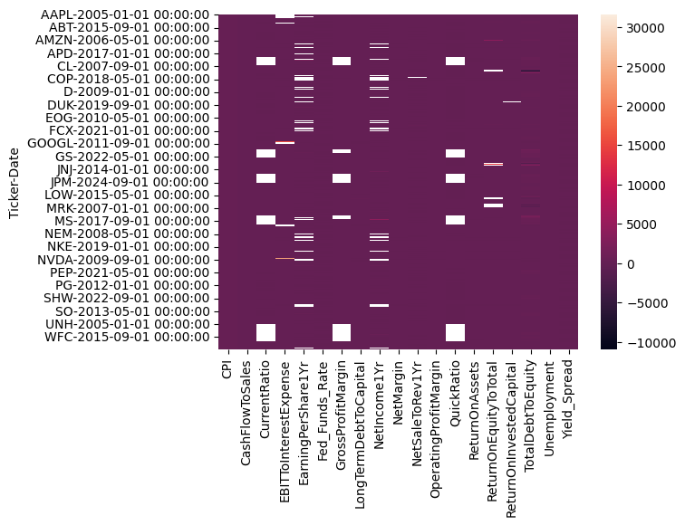

```python
sns.heatmap(pivot_df)
```

```python
from sklearn.preprocessing import MinMaxScaler

# Create a MinMaxScaler instance
scaler = MinMaxScaler()

# Apply scaling to the numerical columns of pivot_df
pivot_df_scaled = pivot_df.copy()
pivot_df_scaled[numerical_cols] = scaler.fit_transform(pivot_df[numerical_cols])

# Display the head of the scaled pivot_df to verify
display(pivot_df_scaled.head())
```

| Ticker | Date | CPI | CashFlowToSales | CurrentRatio | EBITToInterestExpense | EarningPerShare1Yr | Fed_Funds_Rate | GrossProfitMargin | LongTermDebtToCapital | NetIncome1Yr | NetMargin | NetSaleToRev1Yr | OperatingProfitMargin | QuickRatio | ReturnOnAssets | ReturnOnEquityToTotal | ReturnOnInvestedCapital | TotalDebtToEquity | Unemployment | Yield_Spread |
| --- | --- | --- | --- | --- | --- | --- | --- | --- | --- | --- | --- | --- | --- | --- | --- | --- | --- | --- | --- | --- |
| AAPL | 2005-01-01 | 0.000000 | 0.199154 | 0.219218 | NaN | 0.062986 | 0.422348 | 0.376195 | 0.0 | 0.102661 | 0.68396 | 0.493308 | 0.389613 | 0.23151 | 0.49741 | 0.005055 | 0.601131 | 0.620407 | 0.166667 | 0.513298 |
|  | 2005-02-01 | 0.006349 | 0.199154 | 0.219218 | NaN | 0.062986 | 0.464015 | 0.376195 | 0.0 | 0.102661 | 0.68396 | 0.493308 | 0.389613 | 0.23151 | 0.49741 | 0.005055 | 0.601131 | 0.620407 | 0.175439 | 0.457447 |
|  | 2005-03-01 | 0.011904 | 0.199154 | 0.219218 | NaN | 0.062986 | 0.488636 | 0.376195 | 0.0 | 0.102661 | 0.68396 | 0.493308 | 0.389613 | 0.23151 | 0.49741 | 0.005055 | 0.601131 | 0.620407 | 0.157895 | 0.452128 |
|  | 2005-04-01 | 0.016666 | 0.199154 | 0.219218 | NaN | 0.062986 | 0.518939 | 0.376195 | 0.0 | 0.102661 | 0.68396 | 0.493308 | 0.389613 | 0.23151 | 0.49741 | 0.005055 | 0.601131 | 0.620407 | 0.157895 | 0.430851 |
|  | 2005-05-01 | 0.015873 | 0.199154 | 0.219218 | NaN | 0.062986 | 0.558712 | 0.376195 | 0.0 | 0.102661 | 0.68396 | 0.493308 | 0.389613 | 0.23151 | 0.49741 | 0.005055 | 0.601131 | 0.620407 | 0.149123 | 0.380319 |

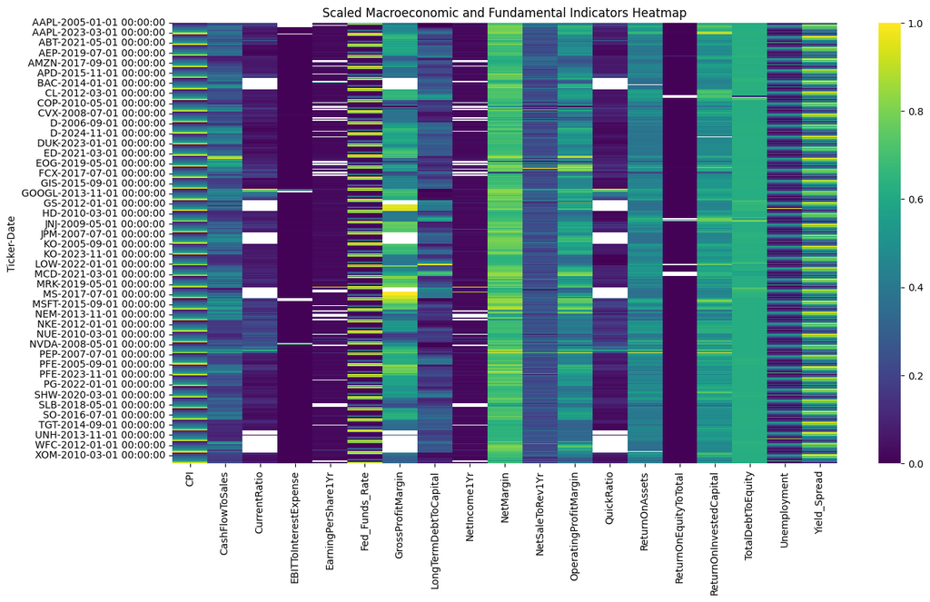

```python
import seaborn as sns
import matplotlib.pyplot as plt

# Plot the heatmap of the scaled pivot_df
plt.figure(figsize=(15, 8))
sns.heatmap(pivot_df_scaled, cmap='viridis')
plt.title('Scaled Macroeconomic and Fundamental Indicators Heatmap')
plt.show()
```

To make the date information more prominent, let's filter the `pivot_df_scaled` to focus on a single ticker, for example, 'AAPL'. This will allow us to see how the various indicators change over time for that specific company.

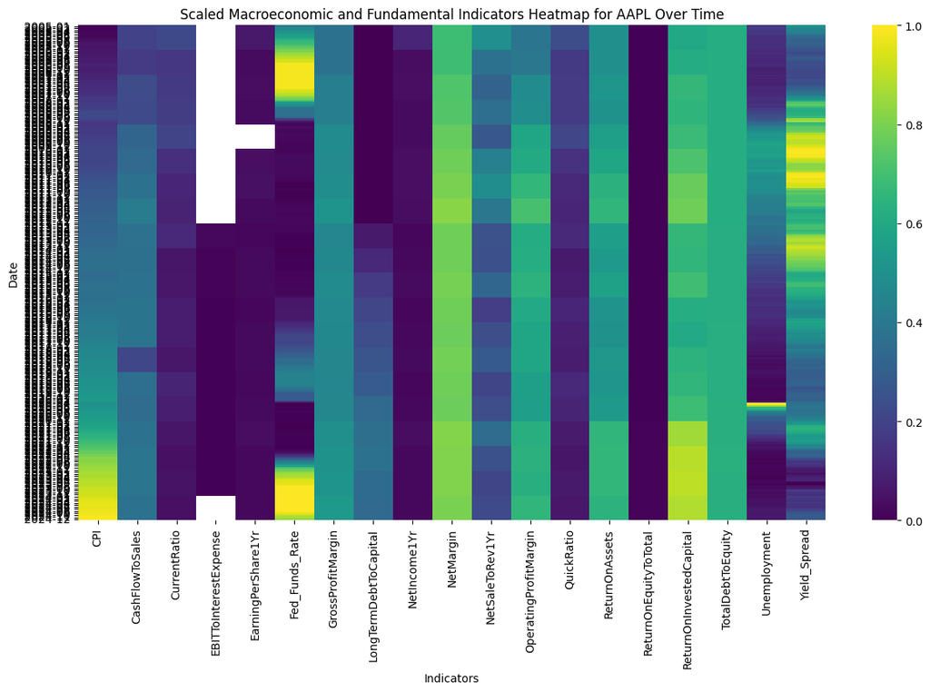

```python
# Select a single ticker to visualize (e.g., 'AAPL')
single_ticker = 'AAPL'
filtered_df_scaled = pivot_df_scaled.loc[single_ticker]

# Ensure the Date is part of the index for plotting
# For multi-index, if you loc a specific ticker, Date becomes the new index.
# We might want to reset index for clear x-axis labels if preferred, but heatmap usually takes index as y-axis.
# For a single ticker, the index is now 'Date'.

plt.figure(figsize=(15, 8))
sns.heatmap(filtered_df_scaled, cmap='viridis', yticklabels=filtered_df_scaled.index.strftime('%Y-%m'))
plt.title(f'Scaled Macroeconomic and Fundamental Indicators Heatmap for {single_ticker} Over Time')
plt.xlabel('Indicators')
plt.ylabel('Date')
plt.show()
```

Let's now create a heatmap that aggregates the data by year across all tickers to observe overall yearly trends.

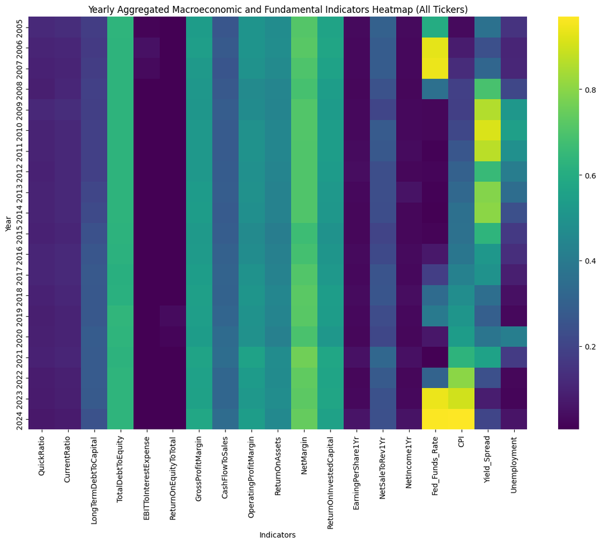

```python
# Reset the index to access 'Date' as a column
aggregated_df = pivot_df_scaled.reset_index()

# Extract the year from the 'Date' column
aggregated_df['Year'] = aggregated_df['Date'].dt.year

# Group by year and calculate the mean for all numerical columns
# Exclude 'Ticker' as it's a categorical identifier and not relevant for numerical aggregation
yearly_avg_df = aggregated_df.groupby('Year')[numerical_cols].mean()

# Plot the heatmap of the yearly aggregated data
plt.figure(figsize=(15, 10))
sns.heatmap(yearly_avg_df, cmap='viridis')
plt.title('Yearly Aggregated Macroeconomic and Fundamental Indicators Heatmap (All Tickers)')
plt.xlabel('Indicators')
plt.ylabel('Year')
plt.show()
```

```python
lseg_fred.info()
```

```
<class 'pandas.core.frame.DataFrame'>
RangeIndex: 9552 entries, 0 to 9551
Data columns (total 21 columns):
 #   Column                   Non-Null Count  Dtype
---  ------                   --------------  -----
 0   Ticker                   9552 non-null   object
 1   Date                     9552 non-null   datetime64[ns]
 2   QuickRatio               8124 non-null   float64
 3   CurrentRatio             8124 non-null   float64
 4   LongTermDebtToCapital    9552 non-null   float64
 5   TotalDebtToEquity        9552 non-null   float64
 6   EBITToInterestExpense    9360 non-null   float64
 7   ReturnOnEquityToTotal    9348 non-null   float64
 8   GrossProfitMargin        8412 non-null   float64
 9   CashFlowToSales          9552 non-null   float64
 10  OperatingProfitMargin    9552 non-null   float64
 11  ReturnOnAssets           9528 non-null   float64
 12  NetMargin                9552 non-null   float64
 13  ReturnOnInvestedCapital  9540 non-null   float64
 14  EarningPerShare1Yr       8700 non-null   float64
 15  NetSaleToRev1Yr          9528 non-null   float64
 16  NetIncome1Yr             8808 non-null   float64
 17  Fed_Funds_Rate           9552 non-null   float64
 18  CPI                      9552 non-null   float64
 19  Yield_Spread             9552 non-null   float64
 20  Unemployment             9552 non-null   float64
dtypes: datetime64[ns](1), float64(19), object(1)
memory usage: 1.5+ MB
```

```python
target = 'ReturnOnEquityToTotal'
lseg_fred = lseg_fred.dropna(subset=[target])
lseg_fred.info()
```

```
<class 'pandas.core.frame.DataFrame'>
Index: 9348 entries, 0 to 9551
Data columns (total 21 columns):
 #   Column                   Non-Null Count  Dtype
---  ------                   --------------  -----
 0   Ticker                   9348 non-null   object
 1   Date                     9348 non-null   datetime64[ns]
 2   QuickRatio               7920 non-null   float64
 3   CurrentRatio             7920 non-null   float64
 4   LongTermDebtToCapital    9348 non-null   float64
 5   TotalDebtToEquity        9348 non-null   float64
 6   EBITToInterestExpense    9156 non-null   float64
 7   ReturnOnEquityToTotal    9348 non-null   float64
 8   GrossProfitMargin        8208 non-null   float64
 9   CashFlowToSales          9348 non-null   float64
 10  OperatingProfitMargin    9348 non-null   float64
 11  ReturnOnAssets           9324 non-null   float64
 12  NetMargin                9348 non-null   float64
 13  ReturnOnInvestedCapital  9336 non-null   float64
 14  EarningPerShare1Yr       8496 non-null   float64
 15  NetSaleToRev1Yr          9324 non-null   float64
 16  NetIncome1Yr             8604 non-null   float64
 17  Fed_Funds_Rate           9348 non-null   float64
 18  CPI                      9348 non-null   float64
 19  Yield_Spread             9348 non-null   float64
 20  Unemployment             9348 non-null   float64
dtypes: datetime64[ns](1), float64(19), object(1)
memory usage: 1.6+ MB
```

Perfect! We can now begin building the primary steps for our model. The goal is to build a superscore metric out of our many available features to predict future preformance of individual stocks. First, we will analyze which features are the most impactful to the successful prediction.

```python
# Train test split
from sklearn.model_selection import train_test_split

x = lseg_fred.drop(columns=[target, 'Ticker', 'Date'])
y = lseg_fred[target]

x_train, x_test, y_train, y_test = train_test_split(x, y, test_size=0.2, random_state=42)
```

```python
from sklearn.ensemble import RandomForestRegressor
import matplotlib.pyplot as plt
import pandas as pd

# Initialize the Random Forest Regressor
rf_model = RandomForestRegressor(n_estimators=100, random_state=42)

# Train the model
rf_model.fit(x_train, y_train)
```

```
RandomForestRegressor(random_state=42)
```

```python
# Get feature importances from the trained model
feature_importances = rf_model.feature_importances_

# Create a pandas Series for better visualization
features_df = pd.Series(feature_importances, index=x_train.columns)

# Sort the features by importance
features_df = features_df.sort_values(ascending=False)
display(features_df)

# Plot the feature importances
#plt.figure(figsize=(12, 8))
#features_df.plot(kind='bar')
#plt.title('Feature Importances from Random Forest Regressor')
#plt.ylabel('Importance')
#plt.xlabel('Feature')
#plt.xticks(rotation=90)
#plt.tight_layout()
#plt.show()
```

|  | 0 |
| --- | --- |
| TotalDebtToEquity | 0.855795 |
| LongTermDebtToCapital | 0.131195 |
| ReturnOnAssets | 0.002988 |
| CurrentRatio | 0.002448 |
| QuickRatio | 0.002131 |
| ReturnOnInvestedCapital | 0.001543 |
| GrossProfitMargin | 0.001230 |
| CashFlowToSales | 0.000780 |
| NetMargin | 0.000627 |
| NetIncome1Yr | 0.000369 |
| EarningPerShare1Yr | 0.000295 |
| Unemployment | 0.000228 |
| EBITToInterestExpense | 0.000135 |
| Yield_Spread | 0.000056 |
| Fed_Funds_Rate | 0.000051 |
| OperatingProfitMargin | 0.000051 |
| CPI | 0.000050 |
| NetSaleToRev1Yr | 0.000025 |

**dtype:** float64

We can see that total debt (to equity) seems to be one of the most important indicators for predicting equity performance. We will use this to inform our choices of data when building our final model.

### Next steps

Next, we are working on accessing the other two data sets. Then, we need to decide how to best handle and incorperate the date data type into our overall dataset.

```python
## Creates a HTML file of the notebook in Drive
## Download this and upload to github pages
%%shell
jupyter nbconvert --to html "/content/drive/MyDrive/Loyno/2025-26/Spring/Data Science project/Data Science Project/Data_Sci_Project.ipynb"
```

```
[NbConvertApp] Converting notebook /content/drive/MyDrive/Loyno/2025-26/Spring/Data Science project/Data Science Project/Data_Sci_Project.ipynb to html
[NbConvertApp] Writing 363769 bytes to /content/drive/MyDrive/Loyno/2025-26/Spring/Data Science project/Data Science Project/Data_Sci_Project.html
```